# Entrega 3: código del informe final

Determinantes socioeconómicos e institucionales del desempeño en las pruebas Saber 11 (2020-2)

Autor/a

David Libreros, Mateo Puente, Nicolás González, Santiago Díaz

Fecha de publicación

22 de noviembre de 2026

# Presentación

Este `.qmd` calcula y exporta las tablas y figuras que usa el PDF generado desde `reports/latex_entrega_3/main.tex`, junto con las cifras que el texto cita. Las secciones 1 y 2 reproducen el análisis descriptivo de la Entrega 2 y la sección 3 añade el análisis multivariado del informe final. Contiene lo que el documento usa y, como respaldo, las frecuencias completas de las variables cualitativas. Las tablas y figuras exportadas están listadas en `FIGURAS_DOC` y `TABLAS_DOC` dentro de `R/exportacion.R`.

La opción `aed.entrega` decide la carpeta de destino de los artefactos, de modo que este archivo escribe en `latex_entrega_3` sin tocar lo que generó la Entrega 2.

```r
options(aed.entrega = 3)
```

# 0. Preparación y configuración

## 0.1 Carga de la base

`R/preparacion.R` reproduce la preparación de la Entrega 1 (con una re-selección de las variables): selección de las 21 columnas, filtros de validez y de cuestionario completo, recodificación a factores y creación de `EDAD`.

```r
source(here::here("R", "preparacion.R"))

dim(dataset)
```

```
[1] 478665     21
```

```r
c(cualitativas = length(vars_cuali), cuantitativas = length(vars_cuanti))
```

```
 cualitativas cuantitativas
           12             8
```

## 0.2 Funciones auxiliares

- **`R/exportacion.R`**: rutas de salida, formato numérico en convención española y la escritura de las tablas en LaTeX. Hecho con IA para automatizar el paso de tablas y figuras al documento sin capturas de pantalla.
- **`R/graficos.R`**: tema de las figuras, paleta y funciones de tablas y gráficos.

El orden importa: `graficos.R` usa las funciones de formato de `exportacion.R`.

```r
source(here::here("R", "exportacion.R"))
source(here::here("R", "graficos.R"))
```

# 1. Análisis descriptivo univariado

## 1.1 Variables cualitativas

### 1.1.1 Tabla de frecuencias

Condiciones del hogar y características del establecimiento. Incluye las variables del planteamiento (naturaleza, zona, nivel socioeconómico) y las de mayor asociación con el desempeño.

```r
etiq <- c("Sin Estrato" = "Sin estrato", "No" = "No", "Si" = "Sí",
          "OFICIAL" = "Oficial", "NO OFICIAL" = "No oficial",
          "URBANO" = "Urbana", "RURAL" = "Rural")

izq <- bloque_frec(c("FAMI_ESTRATOVIVIENDA", "FAMI_TIENEINTERNET"), etiq)
der <- bloque_frec(c("ESTU_NSE_ESTABLECIMIENTO", "COLE_NATURALEZA",
                     "COLE_AREA_UBICACION"), etiq)

tex_tabla_doble(
  izq, der, "tab-frec-clave",
  "Frecuencias absolutas y relativas de las variables del hogar y del establecimiento.",
  "tab:frec-clave",
  titulos = c("Hogar", "Establecimiento educativo")
)
```

### 1.1.2 Frecuencias de todas las variables cualitativas

El documento solo presenta las variables de mayor relevancia para la pregunta; aquí quedan las tablas de frecuencias completas de las 12 cualitativas.

```r
for (v in vars_cuali) {
  print(knitr::kable(tabla_frec(v), digits = 2, caption = v))
  cat("\n\n")
}
```

ESTU_GENERO

| nivel | n | pct |
| --- | --- | --- |
| F | 262412 | 54.82 |
| M | 216246 | 45.18 |
| (Sin dato) | 7 | 0.00 |

ESTU_DEDICACIONLECTURADIARIA

| nivel | n | pct | pct_acum |
| --- | --- | --- | --- |
| No leo por entretenimiento | 93483 | 19.53 | 19.53 |
| 30 minutos o menos | 184936 | 38.64 | 58.17 |
| Entre 30 y 60 minutos | 129255 | 27.00 | 85.17 |
| Entre 1 y 2 horas | 49793 | 10.40 | 95.57 |
| Más de 2 horas | 21198 | 4.43 | 100.00 |

ESTU_HORASSEMANATRABAJA

| nivel | n | pct | pct_acum |
| --- | --- | --- | --- |
| 0 | 288878 | 60.35 | 60.35 |
| Menos de 10 horas | 93106 | 19.45 | 79.80 |
| Entre 11 y 20 horas | 49905 | 10.43 | 90.23 |
| Entre 21 y 30 horas | 21169 | 4.42 | 94.65 |
| Más de 30 horas | 25607 | 5.35 | 100.00 |

FAMI_ESTRATOVIVIENDA

| nivel | n | pct | pct_acum |
| --- | --- | --- | --- |
| Sin Estrato | 15130 | 3.16 | 3.16 |
| Estrato 1 | 149851 | 31.31 | 34.47 |
| Estrato 2 | 179122 | 37.42 | 71.89 |
| Estrato 3 | 101785 | 21.26 | 93.15 |
| Estrato 4 | 23003 | 4.81 | 97.96 |
| Estrato 5 | 6811 | 1.42 | 99.38 |
| Estrato 6 | 2963 | 0.62 | 100.00 |

FAMI_EDUCACIONMADRE

| nivel | n | pct |
| --- | --- | --- |
| Ninguno | 11736 | 2.45 |
| Primaria incompleta | 68948 | 14.40 |
| Primaria completa | 44622 | 9.32 |
| Secundaria (Bachillerato) incompleta | 66441 | 13.88 |
| Secundaria (Bachillerato) completa | 134342 | 28.07 |
| Técnica o tecnológica incompleta | 14777 | 3.09 |
| Técnica o tecnológica completa | 49536 | 10.35 |
| Educación profesional incompleta | 12348 | 2.58 |
| Educación profesional completa | 55211 | 11.53 |
| Postgrado | 11060 | 2.31 |
| No sabe | 8524 | 1.78 |
| No Aplica | 1120 | 0.23 |

FAMI_NUMLIBROS

| nivel | n | pct | pct_acum |
| --- | --- | --- | --- |
| 0 A 10 LIBROS | 201162 | 42.03 | 42.03 |
| 11 A 25 LIBROS | 148213 | 30.96 | 72.99 |
| 26 A 100 LIBROS | 98461 | 20.57 | 93.56 |
| MÁS DE 100 LIBROS | 30829 | 6.44 | 100.00 |

FAMI_TIENEINTERNET

| nivel | n | pct |
| --- | --- | --- |
| No | 143823 | 30.05 |
| Si | 334842 | 69.95 |

COLE_NATURALEZA

| nivel | n | pct |
| --- | --- | --- |
| OFICIAL | 371156 | 77.54 |
| NO OFICIAL | 107509 | 22.46 |

COLE_JORNADA

| nivel | n | pct |
| --- | --- | --- |
| MAÑANA | 190179 | 39.73 |
| TARDE | 46276 | 9.67 |
| NOCHE | 18531 | 3.87 |
| UNICA | 126389 | 26.40 |
| COMPLETA | 74490 | 15.56 |
| SABATINA | 22800 | 4.76 |

COLE_AREA_UBICACION

| nivel | n | pct |
| --- | --- | --- |
| URBANO | 400502 | 83.67 |
| RURAL | 78163 | 16.33 |

COLE_DEPTO_UBICACION

| nivel | n | pct |
| --- | --- | --- |
| AMAZONAS | 583 | 0.12 |
| ANTIOQUIA | 67391 | 14.08 |
| ARAUCA | 2812 | 0.59 |
| ATLANTICO | 26977 | 5.64 |
| BOGOTÁ | 73499 | 15.35 |
| BOLIVAR | 22543 | 4.71 |
| BOYACA | 14593 | 3.05 |
| CALDAS | 9603 | 2.01 |
| CAQUETA | 3688 | 0.77 |
| CASANARE | 5109 | 1.07 |
| CAUCA | 11542 | 2.41 |
| CESAR | 11780 | 2.46 |
| CHOCO | 3954 | 0.83 |
| CORDOBA | 18515 | 3.87 |
| CUNDINAMARCA | 33121 | 6.92 |
| GUAINIA | 257 | 0.05 |
| GUAVIARE | 766 | 0.16 |
| HUILA | 11517 | 2.41 |
| LA GUAJIRA | 7256 | 1.52 |
| MAGDALENA | 14266 | 2.98 |
| META | 11085 | 2.32 |
| NARIÑO | 14370 | 3.00 |
| NORTE SANTANDER | 13920 | 2.91 |
| PUTUMAYO | 3418 | 0.71 |
| QUINDIO | 5551 | 1.16 |
| RISARALDA | 8961 | 1.87 |
| SAN ANDRES | 568 | 0.12 |
| SANTANDER | 22834 | 4.77 |
| SUCRE | 9575 | 2.00 |
| TOLIMA | 14881 | 3.11 |
| VALLE | 32976 | 6.89 |
| VAUPES | 288 | 0.06 |
| VICHADA | 466 | 0.10 |

ESTU_NSE_ESTABLECIMIENTO

| nivel | n | pct | pct_acum |
| --- | --- | --- | --- |
| NSE 1 | 23728 | 4.96 | 4.96 |
| NSE 2 | 246150 | 51.42 | 56.38 |
| NSE 3 | 186182 | 38.90 | 95.28 |
| NSE 4 | 22605 | 4.72 | 100.00 |

### 1.1.3 Variables ordinales del estudiante y del hogar

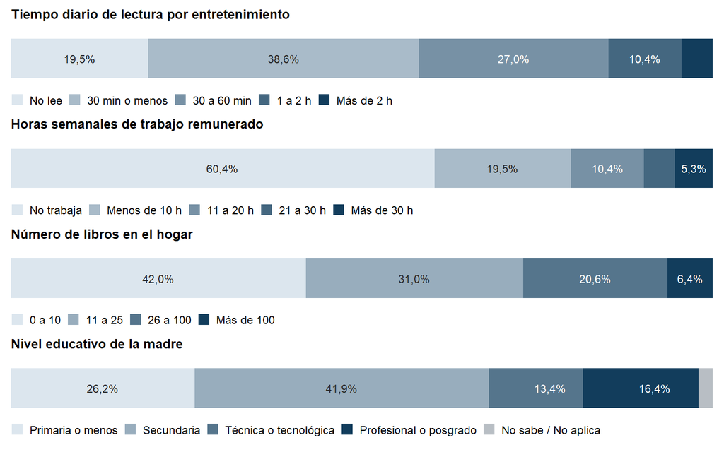

Figura 1

```r
educ_madre <- forcats::fct_collapse(
  dataset$FAMI_EDUCACIONMADRE,
  "Primaria o menos"       = c("Ninguno", "Primaria incompleta", "Primaria completa"),
  "Secundaria"             = c("Secundaria (Bachillerato) incompleta",
                               "Secundaria (Bachillerato) completa"),
  "Técnica o tecnológica"  = c("Técnica o tecnológica incompleta",
                               "Técnica o tecnológica completa"),
  "Profesional o posgrado" = c("Educación profesional incompleta",
                               "Educación profesional completa", "Postgrado"),
  "No sabe / No aplica"    = c("No sabe", "No Aplica")
)

lectura <- forcats::fct_recode(
  dataset$ESTU_DEDICACIONLECTURADIARIA,
  "No lee" = "No leo por entretenimiento", "30 min o menos" = "30 minutos o menos",
  "30 a 60 min" = "Entre 30 y 60 minutos", "1 a 2 h" = "Entre 1 y 2 horas",
  "Más de 2 h" = "Más de 2 horas")

trabajo <- forcats::fct_recode(
  dataset$ESTU_HORASSEMANATRABAJA,
  "No trabaja" = "0", "Menos de 10 h" = "Menos de 10 horas",
  "11 a 20 h" = "Entre 11 y 20 horas", "21 a 30 h" = "Entre 21 y 30 horas",
  "Más de 30 h" = "Más de 30 horas")

libros <- forcats::fct_recode(
  dataset$FAMI_NUMLIBROS,
  "0 a 10" = "0 A 10 LIBROS", "11 a 25" = "11 A 25 LIBROS",
  "26 a 100" = "26 A 100 LIBROS", "Más de 100" = "MÁS DE 100 LIBROS")

exportar_fig(
  graf_ord_apilado(lectura, "Tiempo diario de lectura por entretenimiento") /
  graf_ord_apilado(trabajo, "Horas semanales de trabajo remunerado") /
  graf_ord_apilado(libros,  "Número de libros en el hogar") /
  graf_ord_apilado(educ_madre, "Nivel educativo de la madre",
                   gris = "No sabe / No aplica"),
  "fig-ordinales", alto = 3.4)
```

### 1.1.4 Cifras citadas en el texto

Porcentajes que el documento menciona y que no aparecen directamente en la tabla ni en la figura: agregados de varios niveles y las variables que solo se describen en el texto.

```r
pct <- \(x, nivel) round(100 * mean(x %in% nivel), 1)

list(
  estratos_1_3      = pct(dataset$FAMI_ESTRATOVIVIENDA, paste("Estrato", 1:3)),
  estratos_5_6      = pct(dataset$FAMI_ESTRATOVIVIENDA, paste("Estrato", 5:6)),
  nse_2_3           = pct(dataset$ESTU_NSE_ESTABLECIMIENTO, c("NSE 2", "NSE 3")),
  lee_30_o_menos    = pct(lectura, c("No lee", "30 min o menos")),
  trabaja_mas_20    = pct(trabajo, c("21 a 30 h", "Más de 30 h")),
  femenino          = pct(dataset$ESTU_GENERO, "F"),
  jornada_manana    = pct(dataset$COLE_JORNADA, "MAÑANA"),
  noche_sabatina    = pct(dataset$COLE_JORNADA, c("NOCHE", "SABATINA")),
  bogota_antioquia  = pct(dataset$COLE_DEPTO_UBICACION, c("BOGOTÁ", "ANTIOQUIA")),
  deptos_menor_0.2  = sum(prop.table(table(dataset$COLE_DEPTO_UBICACION)) < 0.002)
)
```

```
$estratos_1_3
[1] 90

$estratos_5_6
[1] 2

$nse_2_3
[1] 90.3

$lee_30_o_menos
[1] 58.2

$trabaja_mas_20
[1] 9.8

$femenino
[1] 54.8

$jornada_manana
[1] 39.7

$noche_sabatina
[1] 8.6

$bogota_antioquia
[1] 29.4

$deptos_menor_0.2
[1] 6
```

## 1.2 Variables cuantitativas

### 1.2.1 Medidas de resumen

```r
res <- resumen_cuant(vars_cuanti)

ETIQ <- c(EDAD = "Edad", ESTU_INSE_INDIVIDUAL = "INSE",
          PUNT_LECTURA_CRITICA = "Lectura", PUNT_MATEMATICAS = "Matem.",
          PUNT_C_NATURALES = "C. Nat.", PUNT_SOCIALES_CIUDADANAS = "Sociales",
          PUNT_INGLES = "Inglés", PUNT_GLOBAL = "Global")

MEDIDAS <- tibble::tribble(
  ~clave,      ~etiqueta,                        ~dig, ~grupo,
  "n_na",      "Datos faltantes",                   0, "Recuento",
  "media",     "Media",                             2, "Medidas de tendencia central",
  "mediana",   "Mediana",                           2, "Medidas de tendencia central",
  "moda",      "Moda",                              2, "Medidas de tendencia central",
  "minimo",    "Mínimo",                            2, "Medidas de dispersión",
  "maximo",    "Máximo",                            2, "Medidas de dispersión",
  "rango",     "Rango",                             2, "Medidas de dispersión",
  "varianza",  "Varianza",                          1, "Medidas de dispersión",
  "desv_est",  "Desviación estándar",               2, "Medidas de dispersión",
  "cv",        "Coeficiente de variación (\\%)",    1, "Medidas de dispersión",
  "Q1",        "Primer cuartil (Q1)",               2, "Medidas de posición y forma",
  "Q3",        "Tercer cuartil (Q3)",               2, "Medidas de posición y forma",
  "RIC",       "Rango intercuartílico",             2, "Medidas de posición y forma",
  "asimetria", "Coeficiente de asimetría",          2, "Medidas de posición y forma"
)

tab_res <- purrr::pmap_dfr(MEDIDAS, function(clave, etiqueta, dig, grupo) {
  fila <- as.list(celda(res[[clave]], dig))
  names(fila) <- res$variable
  c(list(medida = etiqueta), fila)
})

tex_longtable(
  tab_res, "tbl-resumen-cuant",
  "Medidas de tendencia central, dispersión, posición y forma de las variables cuantitativas.",
  "tab:resumen-cuant",
  align     = paste(c("l", rep("r", length(vars_cuanti))), collapse = " "),
  cabeceras = c("Medida", unname(ETIQ[res$variable])),
  grupos    = MEDIDAS$grupo,
  tamano    = "\\tiny\\setstretch{1}\\setlength{\\tabcolsep}{4pt}",
  nota      = sprintf("Base de %s estudiantes. La moda no se reporta en \\texttt{EDAD} ni en \\texttt{ESTU\\_INSE\\_INDIVIDUAL} por ser continuas. Los componentes se miden de 0 a 100 y el puntaje global de 0 a 500.",
                      num(nrow(dataset), 0))
)
knitr::kable(tab_res)
```

Tabla 1

| medida | EDAD | ESTU_INSE_INDIVIDUAL | PUNT_LECTURA_CRITICA | PUNT_MATEMATICAS | PUNT_C_NATURALES | PUNT_SOCIALES_CIUDADANAS | PUNT_INGLES | PUNT_GLOBAL |
| --- | --- | --- | --- | --- | --- | --- | --- | --- |
| Datos faltantes | 267 | 2 | 0 | 0 | 0 | 0 | 220 | 0 |
| Media | 17,90 | 50,86 | 52,28 | 51,19 | 48,40 | 48,37 | 47,13 | 249,17 |
| Mediana | 17,38 | 50,69 | 52,00 | 51,00 | 48,00 | 48,00 | 45,00 | 246,00 |
| Moda | — | — | 54,00 | 53,00 | 47,00 | 39,00 | 42,00 | 240,00 |
| Mínimo | 13,03 | 14,28 | 0,00 | 0,00 | 0,00 | 0,00 | 0,00 | 23,00 |
| Máximo | 78,92 | 84,84 | 100,00 | 100,00 | 100,00 | 100,00 | 100,00 | 500,00 |
| Rango | 65,90 | 70,55 | 100,00 | 100,00 | 100,00 | 100,00 | 100,00 | 477,00 |
| Varianza | 6,9 | 89,4 | 101,6 | 134,0 | 108,1 | 142,4 | 123,7 | 2.338,7 |
| Desviación estándar | 2,63 | 9,46 | 10,08 | 11,58 | 10,40 | 11,93 | 11,12 | 48,36 |
| Coeficiente de variación (%) | 14,7 | 18,6 | 19,3 | 22,6 | 21,5 | 24,7 | 23,6 | 19,4 |
| Primer cuartil (Q1) | 16,89 | 44,36 | 45,00 | 43,00 | 40,00 | 39,00 | 39,00 | 212,00 |
| Tercer cuartil (Q3) | 18,21 | 56,89 | 59,00 | 59,00 | 56,00 | 57,00 | 52,00 | 283,00 |
| Rango intercuartílico | 1,32 | 12,53 | 14,00 | 16,00 | 16,00 | 18,00 | 13,00 | 71,00 |
| Coeficiente de asimetría | 8,26 | 0,19 | 0,06 | 0,17 | 0,32 | 0,33 | 1,04 | 0,36 |

### 1.2.2 Puntaje global

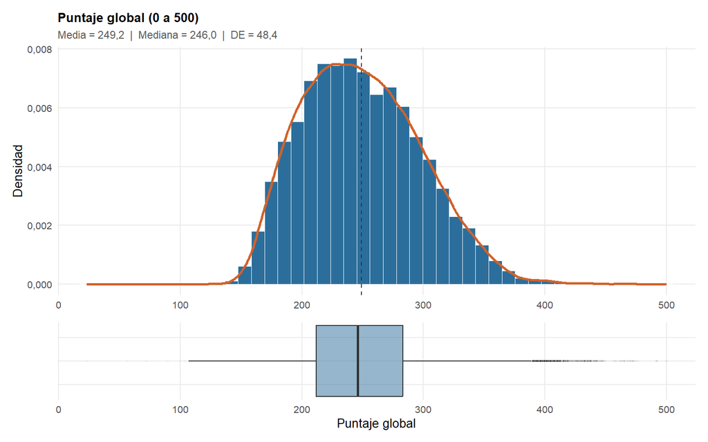

Figura 2

```r
exportar_fig(graf_dist("PUNT_GLOBAL", titulo = "Puntaje global (0 a 500)",
                       unidad = "Puntaje global"),
             "fig-global", alto = 2.8)
```

### 1.2.3 Componentes de la prueba e índice socioeconómico

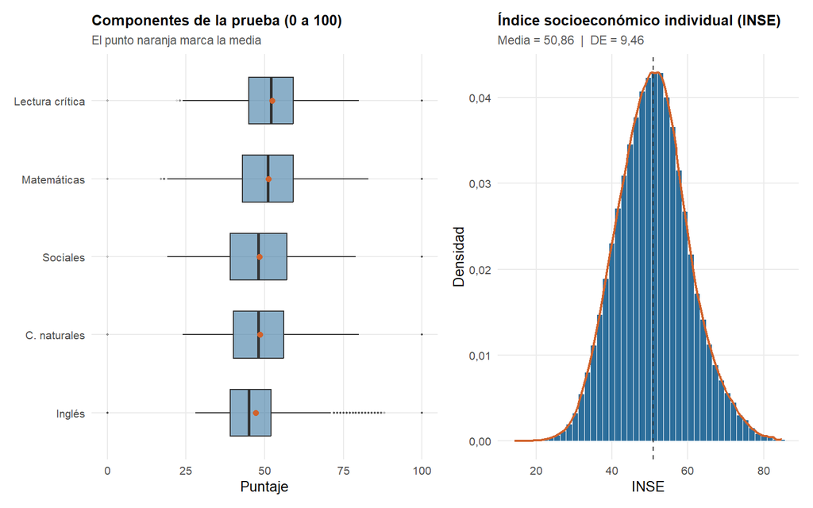

Figura 3

```r
COMP <- c(PUNT_LECTURA_CRITICA = "Lectura crítica", PUNT_MATEMATICAS = "Matemáticas",
          PUNT_C_NATURALES = "C. naturales", PUNT_SOCIALES_CIUDADANAS = "Sociales",
          PUNT_INGLES = "Inglés")

largo_comp <- dataset |>
  dplyr::select(tidyselect::all_of(names(COMP))) |>
  tidyr::pivot_longer(everything(), names_to = "prueba", values_to = "puntaje") |>
  dplyr::filter(!is.na(puntaje)) |>
  dplyr::mutate(prueba = COMP[prueba])

p_comp <- ggplot(largo_comp,
                 aes(x = forcats::fct_reorder(prueba, puntaje, .fun = median),
                     y = puntaje)) +
  geom_boxplot(fill = AZUL, alpha = 0.55, outlier.alpha = 0.02,
               outlier.size = 0.3, width = 0.6) +
  stat_summary(fun = mean, geom = "point", colour = NARANJA, size = 1.6) +
  coord_flip() +
  labs(title = "Componentes de la prueba (0 a 100)",
       subtitle = "El punto naranja marca la media", x = NULL, y = "Puntaje")

inse <- dataset$ESTU_INSE_INDIVIDUAL[!is.na(dataset$ESTU_INSE_INDIVIDUAL)]
p_inse <- ggplot(tibble::tibble(x = inse), aes(x)) +
  geom_histogram(aes(y = after_stat(density)), bins = 45, fill = AZUL,
                 colour = "white", linewidth = 0.12) +
  geom_density(colour = NARANJA, linewidth = 0.8) +
  geom_vline(xintercept = mean(inse), colour = "grey20", linetype = "dashed") +
  scale_y_continuous(labels = label_number(decimal.mark = ",")) +
  labs(title = "Índice socioeconómico individual (INSE)",
       subtitle = paste0("Media = ", num(mean(inse), 2), "  |  DE = ", num(sd(inse), 2)),
       x = "INSE", y = "Densidad")

exportar_fig((p_comp | p_inse) + plot_layout(widths = c(1.15, 1)),
             "fig-componentes-inse", alto = 2.6)
```

### 1.2.4 Edad

En el documento se describe con la tabla de resumen y con el percentil 99, que dimensiona la cola de estudiantes en extraedad.

Puntajes nulos o cercanos a cero: solo un registro tenía `PUNT_GLOBAL = 0` (cero en las cinco pruebas) y se excluyó en `R/preparacion.R`. Los ceros en componentes aislados se conservan.

```r
comp_cero <- rowSums(dataset[names(COMP)] == 0, na.rm = TRUE)
list(registros_con_algun_cero = sum(comp_cero > 0),
     pct = round(100 * mean(comp_cero > 0), 3),
     ceros_por_prueba = colSums(dataset[names(COMP)] == 0, na.rm = TRUE),
     global_min = min(dataset$PUNT_GLOBAL))
```

```
$registros_con_algun_cero
[1] 257

$pct
[1] 0.054

$ceros_por_prueba
    PUNT_LECTURA_CRITICA         PUNT_MATEMATICAS         PUNT_C_NATURALES
                      16                       27                       28
PUNT_SOCIALES_CIUDADANAS              PUNT_INGLES
                      10                      203

$global_min
[1] 23
```

```r
quantile(dataset$EDAD, 0.99, na.rm = TRUE)
```

```
     99%
29.34428
```

# 2. Análisis descriptivo bivariado

## 2.1 Relaciones entre variables cuantitativas

Matriz de correlaciones de las 8 cuantitativas y relación entre el INSE y el puntaje global. Con 478.665 observaciones un diagrama de dispersión clásico produce una mancha uniforme, por lo que se agrupan los puntos en hexágonos y el color codifica la densidad.

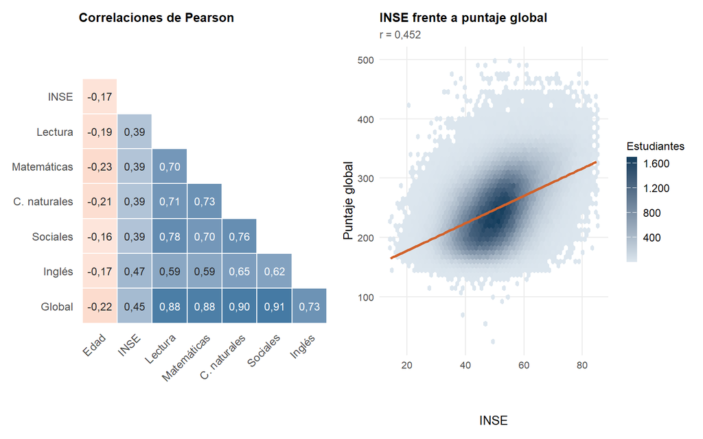

Figura 4

```r
ETIQ_CORTA <- c(EDAD = "Edad", ESTU_INSE_INDIVIDUAL = "INSE",
                PUNT_LECTURA_CRITICA = "Lectura", PUNT_MATEMATICAS = "Matemáticas",
                PUNT_C_NATURALES = "C. naturales", PUNT_SOCIALES_CIUDADANAS = "Sociales",
                PUNT_INGLES = "Inglés", PUNT_GLOBAL = "Global")

M <- cor(dataset[vars_cuanti], use = "pairwise.complete.obs")
dimnames(M) <- list(ETIQ_CORTA[vars_cuanti], ETIQ_CORTA[vars_cuanti])

p_corr <- graf_matriz(M, "Correlaciones de Pearson")

r_inse <- cor(dataset$ESTU_INSE_INDIVIDUAL, dataset$PUNT_GLOBAL, use = "complete.obs")
p_hex <- ggplot(dataset, aes(ESTU_INSE_INDIVIDUAL, PUNT_GLOBAL)) +
  geom_hex(bins = 55) +
  geom_smooth(method = "lm", formula = y ~ x, colour = NARANJA,
              linewidth = 0.9, se = FALSE) +
  scale_fill_gradient(low = "#DCE6EE", high = "#123D5C",
                      labels = label_number(big.mark = ".")) +
  labs(title = "INSE frente a puntaje global",
       subtitle = paste0("r = ", num(r_inse, 3)),
       x = "INSE", y = "Puntaje global", fill = "Estudiantes") +
  theme(legend.key.width = unit(3, "mm"), legend.text = element_text(size = 8.5),
        legend.title = element_text(size = 9))

exportar_fig((p_corr | p_hex) + plot_layout(widths = c(1.1, 1)),
             "fig-corr-inse", alto = 3.8)
```

Cifras citadas en el texto.

```r
M_comp <- M[ETIQ_CORTA[names(COMP)], ETIQ_CORTA[names(COMP)]]
list(
  r_inse_global    = round(r_inse, 3),
  r2_inse_global   = round(100 * r_inse^2, 1),
  r_inse_comp      = round(M["INSE", ETIQ_CORTA[names(COMP)]], 2),
  r_edad_global    = round(M["Edad", "Global"], 2),
  r_min_componentes = round(min(M_comp[lower.tri(M_comp)]), 2),
  r_max_componentes = round(max(M_comp[lower.tri(M_comp)]), 2)
)
```

```
$r_inse_global
[1] 0.452

$r2_inse_global
[1] 20.4

$r_inse_comp
     Lectura  Matemáticas C. naturales     Sociales       Inglés
        0.39         0.39         0.39         0.39         0.47

$r_edad_global
[1] -0.22

$r_min_componentes
[1] 0.59

$r_max_componentes
[1] 0.78
```

```r
M_comp
```

```
               Lectura Matemáticas C. naturales  Sociales    Inglés
Lectura      1.0000000   0.6980909    0.7073943 0.7787977 0.5891075
Matemáticas  0.6980909   1.0000000    0.7340693 0.6976358 0.5888115
C. naturales 0.7073943   0.7340693    1.0000000 0.7619453 0.6477475
Sociales     0.7787977   0.6976358    0.7619453 1.0000000 0.6226534
Inglés       0.5891075   0.5888115    0.6477475 0.6226534 1.0000000
```

## 2.2 Relaciones entre las variables cualitativas y el desempeño

Puntaje global según las cuatro comparaciones del planteamiento. La educación de la madre usa la misma agrupación de la sección 1.1.3, con etiquetas cortas para el panel. Por eso su $\eta^2$ en la figura (variable agrupada) es menor que el de la tabla de asociación, que usa las 12 categorías originales.

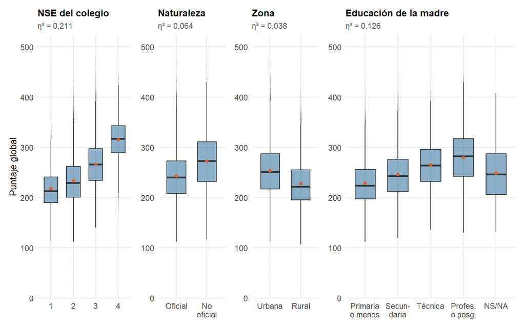

Figura 5

```r
educ_corta <- forcats::fct_recode(
  educ_madre,
  "Primaria\no menos" = "Primaria o menos", "Secun-\ndaria" = "Secundaria",
  "Técnica" = "Técnica o tecnológica", "Profes.\no posg." = "Profesional o posgrado",
  "NS/NA" = "No sabe / No aplica")

naturaleza <- forcats::fct_recode(dataset$COLE_NATURALEZA,
                                  "Oficial" = "OFICIAL", "No\noficial" = "NO OFICIAL")
area <- forcats::fct_recode(dataset$COLE_AREA_UBICACION,
                            "Urbana" = "URBANO", "Rural" = "RURAL")
nse <- factor(dataset$ESTU_NSE_ESTABLECIMIENTO, ordered = FALSE,
              labels = c("1", "2", "3", "4"))

exportar_fig(
  (graf_box(nse, dataset$PUNT_GLOBAL, "NSE del colegio") |
   graf_box(naturaleza, dataset$PUNT_GLOBAL, "Naturaleza") + labs(y = NULL) |
   graf_box(area, dataset$PUNT_GLOBAL, "Zona") + labs(y = NULL) |
   graf_box(educ_corta, dataset$PUNT_GLOBAL, "Educación de la madre") + labs(y = NULL)) +
    plot_layout(widths = c(1.05, 0.75, 0.75, 1.9)),
  "fig-box-clave", alto = 3.0)
```

Medias por grupo citadas en el texto.

```r
media_por <- \(g) round(tapply(dataset$PUNT_GLOBAL, g, mean), 1)
list(
  nse        = media_por(nse),
  naturaleza = media_por(naturaleza),
  area       = media_por(area),
  educ_madre = media_por(educ_madre),
  genero     = media_por(dataset$ESTU_GENERO),
  de_global  = round(sd(dataset$PUNT_GLOBAL), 1)
)
```

```
$nse
    1     2     3     4
217.9 233.3 266.1 314.8

$naturaleza
    Oficial No\noficial
      242.6       271.9

$area
Urbana  Rural
 253.3  228.0

$educ_madre
      Primaria o menos             Secundaria  Técnica o tecnológica
                 228.8                  245.3                  264.3
Profesional o posgrado    No sabe / No aplica
                 279.3                  248.4

$genero
  F   M
246 253

$de_global
[1] 48.4
```

### 2.2.1 Asociación de cada variable con cada puntaje

$\eta^2$ para las cualitativas y $r^2$ para las cuantitativas, ambas interpretables como proporción de la varianza del puntaje que comparte la variable. Se ordenan según el puntaje global.

```r
puntajes <- c("PUNT_GLOBAL", names(COMP))

asoc <- purrr::map_dfr(c(vars_cuali, "EDAD", "ESTU_INSE_INDIVIDUAL"), function(v) {
  vals <- vapply(puntajes, function(p) {
    if (v %in% vars_cuanti) cor(dataset[[v]], dataset[[p]], use = "complete.obs")^2
    else eta2(dataset[[p]], dataset[[v]])
  }, numeric(1))
  tibble::tibble(variable = v, !!!as.list(100 * vals))
}) |>
  dplyr::arrange(dplyr::desc(PUNT_GLOBAL))

# Las mismas etiquetas legibles que usa la tabla de aportes, para que el documento
# no mezcle nombres en código con nombres en prosa.
ETIQ_TABLA <- c(
  ESTU_NSE_ESTABLECIMIENTO     = "NSE del colegio",
  ESTU_INSE_INDIVIDUAL         = "Índice socioeconómico (INSE)",
  FAMI_EDUCACIONMADRE          = "Educación de la madre",
  COLE_JORNADA                 = "Jornada del colegio",
  FAMI_NUMLIBROS               = "Libros en el hogar",
  FAMI_TIENEINTERNET           = "Acceso a internet",
  FAMI_ESTRATOVIVIENDA         = "Estrato de la vivienda",
  COLE_DEPTO_UBICACION         = "Departamento del colegio",
  COLE_NATURALEZA              = "Naturaleza del colegio",
  EDAD                         = "Edad",
  ESTU_HORASSEMANATRABAJA      = "Horas de trabajo",
  COLE_AREA_UBICACION          = "Zona del colegio",
  ESTU_DEDICACIONLECTURADIARIA = "Dedicación a la lectura",
  ESTU_GENERO                  = "Género")

stopifnot(all(asoc$variable %in% names(ETIQ_TABLA)))

tex_longtable(
  data.frame(
    variable = paste0(tex_escape(unname(ETIQ_TABLA[asoc$variable])),
                      ifelse(asoc$variable %in% vars_cuanti, "$^\\dagger$", "")),
    purrr::map_dfr(asoc[puntajes], \(x) celda(x, 1))
  ),
  "tab-asociacion",
  "Porcentaje de la varianza de cada puntaje asociado a cada variable, considerada de forma aislada.",
  "tab:asociacion",
  align     = "l r r r r r r",
  cabeceras = c("Variable", "Global", "Lectura", "Matemáticas", "C. naturales",
                "Sociales", "Inglés"),
  nota      = "Se reporta $100\\,\\eta^2$ para las variables cualitativas y $100\\,r^2$ para las cuantitativas ($^\\dagger$)."
)
asoc
```

```
# A tibble: 14 × 7
   variable   PUNT_GLOBAL PUNT_LECTURA_CRITICA PUNT_MATEMATICAS PUNT_C_NATURALES
   <chr>            <dbl>                <dbl>            <dbl>            <dbl>
 1 ESTU_NSE_…      21.1                15.4               15.4            15.8
 2 ESTU_INSE…      20.4                15.1               15.2            15.3
 3 FAMI_EDUC…      14.2                10.4               10.5            10.9
 4 COLE_JORN…       9.84                6.69               8.06            8.28
 5 FAMI_NUML…       9.31                6.83               6.69            7.30
 6 FAMI_TIEN…       9.23                7.50               6.93            6.65
 7 FAMI_ESTR…       7.23                5.61               5.12            5.13
 8 COLE_DEPT…       6.76                5.02               5.85            5.57
 9 COLE_NATU…       6.43                4.48               4.31            4.71
10 EDAD             4.87                3.72               5.07            4.26
11 ESTU_HORA…       4.79                4.14               2.71            3.71
12 COLE_AREA…       3.75                3.48               2.92            2.34
13 ESTU_DEDI…       2.51                2.38               1.13            1.87
14 ESTU_GENE…       0.521               0.0102             1.61            0.668
# ℹ 2 more variables: PUNT_SOCIALES_CIUDADANAS <dbl>, PUNT_INGLES <dbl>
```

## 2.3 Relaciones entre variables cualitativas

Matriz de $V$ de Cramér entre las 12 cualitativas y composición del nivel socioeconómico del colegio según su naturaleza, el par más asociado.

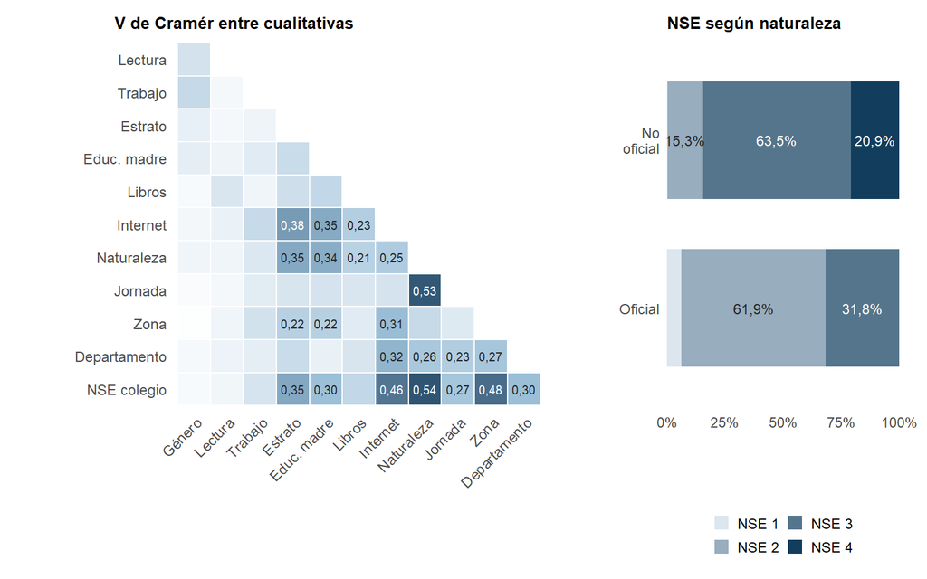

Figura 6

```r
ETIQ_CUALI <- c(ESTU_GENERO = "Género", ESTU_DEDICACIONLECTURADIARIA = "Lectura",
                ESTU_HORASSEMANATRABAJA = "Trabajo", FAMI_ESTRATOVIVIENDA = "Estrato",
                FAMI_EDUCACIONMADRE = "Educ. madre", FAMI_NUMLIBROS = "Libros",
                FAMI_TIENEINTERNET = "Internet", COLE_NATURALEZA = "Naturaleza",
                COLE_JORNADA = "Jornada", COLE_AREA_UBICACION = "Zona",
                COLE_DEPTO_UBICACION = "Departamento", ESTU_NSE_ESTABLECIMIENTO = "NSE colegio")

V <- outer(vars_cuali, vars_cuali,
           Vectorize(\(a, b) if (a == b) 1 else cramer_v(dataset[[a]], dataset[[b]])))
dimnames(V) <- list(ETIQ_CUALI[vars_cuali], ETIQ_CUALI[vars_cuali])

# Solo se rotulan los pares con V >= 0,20; el color muestra el resto
p_v <- graf_matriz(V, "V de Cramér entre cualitativas", limites = c(0, 0.6),
                   colores = c("white", "#9CC0D8", "#123D5C"),
                   min_etiqueta = 0.2, tam = 2.7)

p_nse <- graf_apilado(naturaleza, dataset$ESTU_NSE_ESTABLECIMIENTO,
                      "NSE según naturaleza") +
  guides(fill = guide_legend(nrow = 2)) +
  theme(plot.margin = margin(5, 12, 5, 5))

exportar_fig((p_v | p_nse) + plot_layout(widths = c(2.1, 1)),
             "fig-cramer-nse", alto = 4.8)
```

Pares citados en el texto.

```r
pares <- which(upper.tri(V), arr.ind = TRUE)
tibble::tibble(a = rownames(V)[pares[, 1]], b = colnames(V)[pares[, 2]],
               V = round(V[pares], 3)) |>
  dplyr::arrange(dplyr::desc(V)) |>
  dplyr::slice_head(n = 8)
```

```
# A tibble: 8 × 3
  a           b               V
  <chr>       <chr>       <dbl>
1 Naturaleza  NSE colegio 0.54
2 Naturaleza  Jornada     0.533
3 Zona        NSE colegio 0.484
4 Internet    NSE colegio 0.463
5 Estrato     Internet    0.38
6 Estrato     NSE colegio 0.351
7 Estrato     Naturaleza  0.35
8 Educ. madre Internet    0.347
```

```r
round(100 * prop.table(table(naturaleza, dataset$ESTU_NSE_ESTABLECIMIENTO), 1), 1)
```

```
naturaleza    NSE 1 NSE 2 NSE 3 NSE 4
  Oficial       6.3  61.9  31.8   0.0
  No\noficial   0.3  15.3  63.5  20.9
```

# 3. Análisis multivariado

`R/preparacion_mv.R` añade las variables agrupadas que necesitan las técnicas factoriales (regiones, educación materna en cinco niveles, estratos 5 y 6 fundidos y edad por tramos) y define los bloques de variables. `R/multivariado.R` contiene el ACP, el ACM, el modelo de dependencia y las medidas de adecuación y supuestos.

```r
source(here::here("R", "preparacion_mv.R"))
source(here::here("R", "multivariado.R"))

sapply(c("COLE_REGION", "FAMI_EDUCMADRE_G", "FAMI_ESTRATO_G", "EDAD_TRAMO"),
       function(v) nlevels(dataset[[v]]))
```

```
     COLE_REGION FAMI_EDUCMADRE_G   FAMI_ESTRATO_G       EDAD_TRAMO
               6                5                6                5
```

Coste de cada agrupación, medido como $\eta^2$ sobre el puntaje global antes y después.

```r
data.frame(
  original = c(eta2(dataset$PUNT_GLOBAL, dataset$COLE_DEPTO_UBICACION),
               eta2(dataset$PUNT_GLOBAL, dataset$FAMI_EDUCACIONMADRE),
               eta2(dataset$PUNT_GLOBAL, dataset$FAMI_ESTRATOVIVIENDA),
               cor(dataset$EDAD, dataset$PUNT_GLOBAL, use = "complete.obs")^2),
  agrupada = c(eta2(dataset$PUNT_GLOBAL, dataset$COLE_REGION),
               eta2(dataset$PUNT_GLOBAL, dataset$FAMI_EDUCMADRE_G),
               eta2(dataset$PUNT_GLOBAL, dataset$FAMI_ESTRATO_G),
               eta2(dataset$PUNT_GLOBAL, dataset$EDAD_TRAMO)),
  row.names = c("Departamento / región", "Educación materna",
                "Estrato", "Edad (lineal / por tramos)")
) |> round(4)
```

```
                           original agrupada
Departamento / región        0.0676   0.0460
Educación materna            0.1417   0.1263
Estrato                      0.0723   0.0719
Edad (lineal / por tramos)   0.0487   0.0943
```

## 3.1 Componentes principales de los puntajes

Los cinco puntajes comparten escala, pero se estandarizan igual para que las diferencias de dispersión entre pruebas no pesen en la solución.

```r
acp <- acp_puntajes()

c(n = acp$n, KMO = round(acp$kmo$global, 3))
```

```
         n        KMO
478445.000      0.885
```

```r
round(acp$kmo$por_variable, 3)
```

```
    PUNT_LECTURA_CRITICA         PUNT_MATEMATICAS         PUNT_C_NATURALES
                   0.875                    0.902                    0.874
PUNT_SOCIALES_CIUDADANAS              PUNT_INGLES
                   0.858                    0.936
```

```r
c(chi2 = round(acp$bartlett$chi2, 0), gl = acp$bartlett$gl,
  p = acp$bartlett$p)
```

```
   chi2      gl       p
1663078      10       0
```

```r
round(acp$acp$eig, 3)
```

```
       eigenvalue percentage of variance cumulative percentage of variance
comp 1      3.737                 74.744                            74.744
comp 2      0.460                  9.200                            83.944
comp 3      0.333                  6.669                            90.613
comp 4      0.268                  5.362                            95.975
comp 5      0.201                  4.025                           100.000
```

```r
round(acp$acp$var$cor[, 1:2], 3)
```

```
                         Dim.1  Dim.2
PUNT_LECTURA_CRITICA     0.876 -0.221
PUNT_MATEMATICAS         0.862 -0.154
PUNT_C_NATURALES         0.894 -0.028
PUNT_SOCIALES_CIUDADANAS 0.897 -0.142
PUNT_INGLES              0.790  0.605
```

## 3.2 Correspondencias múltiples del contexto

Nueve variables activas (las socioeconómicas e institucionales) y cuatro suplementarias cualitativas, más los cinco puntajes como cuantitativas suplementarias. Las inercias brutas del ACM subestiman la varianza explicada, así que se corrigen con Benzécri y con Greenacre.

```r
acm <- acm_contexto()

c(n = acm$n, Q = acm$Q, J = acm$J, dimensiones = acm$J - acm$Q)
```

```
          n           Q           J dimensiones
     478171           9          37          28
```

```r
round(cbind(autovalor = acm$acm$eig[1:5, 1], acm$inercias[1:5, ]), 3)
```

```
      autovalor  bruta benzecri greenacre
dim 1     0.365 11.734   83.546    73.618
dim 2     0.212  6.823   13.260    11.684
dim 3     0.145  4.669    1.510     1.330
dim 4     0.139  4.470    1.012     0.892
dim 5     0.128  4.107    0.359     0.317
```

Eta cuadrado de cada variable con las dos primeras dimensiones. Las cuatro suplementarias quedan muy por debajo de las activas.

```r
round(rbind(acm$acm$var$eta2[, 1:2], acm$acm$quali.sup$eta2[, 1:2]), 4)
```

```
                              Dim 1  Dim 2
FAMI_ESTRATO_G               0.4480 0.3367
FAMI_EDUCMADRE_G             0.3773 0.2064
FAMI_NUMLIBROS               0.2371 0.0461
FAMI_TIENEINTERNET           0.3645 0.1241
COLE_NATURALEZA              0.4604 0.0813
COLE_JORNADA                 0.2810 0.2521
COLE_AREA_UBICACION          0.1660 0.2493
COLE_REGION                  0.2659 0.0293
ESTU_NSE_ESTABLECIMIENTO     0.6855 0.5853
ESTU_GENERO                  0.0026 0.0001
ESTU_DEDICACIONLECTURADIARIA 0.0073 0.0007
ESTU_HORASSEMANATRABAJA      0.0419 0.0065
EDAD_TRAMO                   0.0313 0.0046
```

Categorías que más contribuyen a cada dimensión y proyección de los puntajes.

```r
round(sort(acm$acm$var$contrib[, 1], decreasing = TRUE)[1:10], 2)
```

```
            NO OFICIAL                  NSE 4                     No
                 10.86                   8.09                   7.76
              COMPLETA Profesional o posgrado                 Bogotá
                  7.11                   6.51                   5.46
                 NSE 2              Estrato 1                  NSE 3
                  5.10                   5.03                   4.86
                 RURAL
                  4.23
```

```r
round(sort(acm$acm$var$contrib[, 2], decreasing = TRUE)[1:10], 2)
```

```
                 NSE 4                  RURAL                  NSE 1
                 14.38                  10.92                  10.20
              COMPLETA                  NSE 3              Estrato 4
                  8.93                   6.05                   4.88
         Estrato 5 o 6                     No              Estrato 2
                  4.75                   4.54                   4.17
Profesional o posgrado
                  3.35
```

```r
round(acm$acm$quanti.sup$coord[, 1:2], 3)
```

```
                         Dim 1  Dim 2
PUNT_LECTURA_CRITICA     0.415 -0.061
PUNT_MATEMATICAS         0.411 -0.036
PUNT_C_NATURALES         0.415 -0.011
PUNT_SOCIALES_CIUDADANAS 0.426 -0.023
PUNT_INGLES              0.508  0.068
```

### 3.2.1 Plano factorial

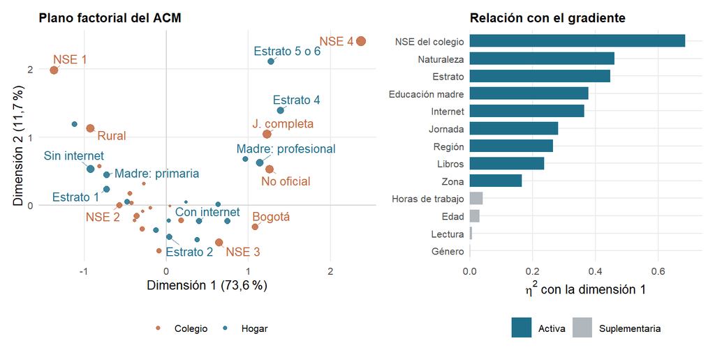

Figura 7

```r
BLOQUE_VAR <- c(FAMI_ESTRATO_G = "Hogar", FAMI_EDUCMADRE_G = "Hogar",
                FAMI_NUMLIBROS = "Hogar", FAMI_TIENEINTERNET = "Hogar",
                COLE_NATURALEZA = "Colegio", COLE_JORNADA = "Colegio",
                COLE_AREA_UBICACION = "Colegio", COLE_REGION = "Colegio",
                ESTU_NSE_ESTABLECIMIENTO = "Colegio")

ETIQ_CAT <- c("No" = "Sin internet", "Si" = "Con internet",
              "OFICIAL" = "Oficial", "NO OFICIAL" = "No oficial",
              "URBANO" = "Urbana", "RURAL" = "Rural",
              "MAÑANA" = "J. mañana", "TARDE" = "J. tarde", "NOCHE" = "J. noche",
              "UNICA" = "J. única", "COMPLETA" = "J. completa",
              "SABATINA" = "J. sabatina",
              "0 A 10 LIBROS" = "0-10 libros", "11 A 25 LIBROS" = "11-25 libros",
              "26 A 100 LIBROS" = "26-100 libros",
              "MÁS DE 100 LIBROS" = "+100 libros",
              "Primaria o menos" = "Madre: primaria",
              "Secundaria" = "Madre: secundaria",
              "Técnica o tecnológica" = "Madre: técnica",
              "Profesional o posgrado" = "Madre: profesional",
              "No sabe o no aplica" = "Madre: no sabe")

coord <- as.data.frame(acm$acm$var$coord[, 1:2])
names(coord) <- c("d1", "d2")
coord$categoria <- rownames(coord)
coord$bloque <- unname(BLOQUE_VAR[acm$categorias$variable])
coord$contrib <- acm$acm$var$contrib[, 1] + acm$acm$var$contrib[, 2]
coord$etiqueta <- dplyr::coalesce(unname(ETIQ_CAT[coord$categoria]), coord$categoria)

# La figura se inserta a media página, de modo que la letra sale a la mitad del
# tamaño exportado. Se rotulan solo las categorías que más contribuyen para que
# las etiquetas quepan al tamaño del resto del documento.
coord$etiqueta[rank(-coord$contrib) > 16] <- ""

inercia <- round(acm$inercias$greenacre[1:2], 1)

p_plano <- ggplot(coord, aes(d1, d2, colour = bloque)) +
  geom_hline(yintercept = 0, linewidth = 0.3, colour = "grey75") +
  geom_vline(xintercept = 0, linewidth = 0.3, colour = "grey75") +
  geom_point(aes(size = contrib), alpha = 0.85) +
  ggrepel::geom_text_repel(aes(label = etiqueta), size = 3.4, max.overlaps = 30,
                           segment.size = 0.2, min.segment.length = 0.1,
                           box.padding = 0.3, show.legend = FALSE) +
  scale_size_continuous(range = c(0.8, 3.4), guide = "none") +
  scale_colour_manual(values = c(Hogar = "#1f6f8b", Colegio = "#c1663c")) +
  labs(x = paste0("Dimensión 1 (", num(inercia[1]), " %)"),
       y = paste0("Dimensión 2 (", num(inercia[2]), " %)"),
       colour = NULL, title = "Plano factorial del ACM") +
  theme(legend.position = "bottom")

eta_df <- rbind(
  data.frame(variable = rownames(acm$acm$var$eta2),
             eta2 = acm$acm$var$eta2[, 1], tipo = "Activa"),
  data.frame(variable = rownames(acm$acm$quali.sup$eta2),
             eta2 = acm$acm$quali.sup$eta2[, 1], tipo = "Suplementaria")
)
ETIQ_VAR <- c(ESTU_NSE_ESTABLECIMIENTO = "NSE del colegio",
              COLE_NATURALEZA = "Naturaleza", FAMI_ESTRATO_G = "Estrato",
              FAMI_EDUCMADRE_G = "Educación madre",
              FAMI_TIENEINTERNET = "Internet", COLE_JORNADA = "Jornada",
              COLE_REGION = "Región", FAMI_NUMLIBROS = "Libros",
              COLE_AREA_UBICACION = "Zona",
              ESTU_HORASSEMANATRABAJA = "Horas de trabajo",
              EDAD_TRAMO = "Edad", ESTU_DEDICACIONLECTURADIARIA = "Lectura",
              ESTU_GENERO = "Género")
eta_df$etiqueta <- unname(ETIQ_VAR[eta_df$variable])

p_eta <- ggplot(eta_df, aes(eta2, reorder(etiqueta, eta2), fill = tipo)) +
  geom_col(width = 0.72) +
  scale_fill_manual(values = c(Activa = "#1f6f8b", Suplementaria = "#b0b7bd")) +
  scale_x_continuous(expand = expansion(mult = c(0, 0.08))) +
  labs(x = expression(eta^2~"con la dimensión 1"), y = NULL, fill = NULL,
       title = "Relación con el gradiente") +
  theme(legend.position = "bottom")

exportar_fig((p_plano | p_eta) + plot_layout(widths = c(1.45, 1)),
             "fig-acm-plano", alto = 4.2)
```

## 3.3 Modelo de dependencia

Regresión lineal multivariada de los cinco puntajes. El aporte propio de cada bloque es lo que el modelo completo pierde al quitarlo, y la diferencia entre la suma de los $R^2$ aislados y el $R^2$ conjunto mide cuánto se superponen.

```r
bloques <- r2_por_bloques(dataset, BLOQUES)

c(n = bloques$n)
```

```
     n
478171
```

```r
round(100 * bloques$completo, 2)
```

```
    Response PUNT_LECTURA_CRITICA         Response PUNT_MATEMATICAS
                            24.99                             26.43
        Response PUNT_C_NATURALES Response PUNT_SOCIALES_CIUDADANAS
                            25.94                             25.55
             Response PUNT_INGLES
                            29.57
```

```r
round(100 * bloques$aislado, 2)
```

```
           Response PUNT_LECTURA_CRITICA Response PUNT_MATEMATICAS
individual                         11.54                     13.50
hogar                              16.15                     15.40
colegio                            12.47                     13.14
geografia                           3.48                      3.63
           Response PUNT_C_NATURALES Response PUNT_SOCIALES_CIUDADANAS
individual                     13.07                             11.58
hogar                          15.80                             16.40
colegio                        12.90                             12.39
geografia                       3.30                              3.80
           Response PUNT_INGLES
individual                10.57
hogar                     21.80
colegio                   16.72
geografia                  3.57
```

```r
round(100 * bloques$propio, 2)
```

```
           Response PUNT_LECTURA_CRITICA Response PUNT_MATEMATICAS
individual                          3.97                      5.15
hogar                               4.44                      3.95
colegio                             2.01                      2.20
geografia                           1.12                      1.29
           Response PUNT_C_NATURALES Response PUNT_SOCIALES_CIUDADANAS
individual                      4.76                              4.41
hogar                           4.21                              4.52
colegio                         2.14                              2.05
geografia                       1.08                              1.24
           Response PUNT_INGLES
individual                 2.89
hogar                      6.70
colegio                    2.80
geografia                  0.49
```

```r
round(100 * bloques$compartida, 2)
```

```
    Response PUNT_LECTURA_CRITICA         Response PUNT_MATEMATICAS
                            18.65                             19.25
        Response PUNT_C_NATURALES Response PUNT_SOCIALES_CIUDADANAS
                            19.13                             18.62
             Response PUNT_INGLES
                            23.09
```

El mismo modelo sustituyendo las variables del hogar y el colegio por los dos índices del ICFES, que resumen esa misma información.

```r
BLOQUES_IDX <- list(
  individual = BLOQUES$individual,
  indices    = VARS_INDICES,
  colegio    = BLOQUES$colegio,
  geografia  = BLOQUES$geografia
)
indices <- r2_por_bloques(dataset, BLOQUES_IDX)

rbind(crudas = 100 * bloques$completo, indices = 100 * indices$completo) |> round(2)
```

```
        Response PUNT_LECTURA_CRITICA Response PUNT_MATEMATICAS
crudas                          24.99                     26.43
indices                         25.87                     27.85
        Response PUNT_C_NATURALES Response PUNT_SOCIALES_CIUDADANAS
crudas                      25.94                             25.55
indices                     27.40                             26.75
        Response PUNT_INGLES
crudas                 29.57
indices                33.37
```

```r
round(100 * indices$propio, 2)
```

```
           Response PUNT_LECTURA_CRITICA Response PUNT_MATEMATICAS
individual                          4.14                      5.29
indices                             5.33                      5.38
colegio                             0.95                      1.12
geografia                           0.88                      0.96
           Response PUNT_C_NATURALES Response PUNT_SOCIALES_CIUDADANAS
individual                      4.89                              4.60
indices                         5.66                              5.72
colegio                         1.00                              0.91
geografia                       0.79                              0.90
           Response PUNT_INGLES
individual                 2.56
indices                   10.50
colegio                    0.68
geografia                  0.28
```

### 3.3.1 Aporte de cada variable sobre el puntaje global

```r
todas <- unlist(BLOQUES, use.names = FALSE)
dmod <- sin_orden(droplevels(
  dataset[complete.cases(dataset[, c(todas, "PUNT_GLOBAL")]),
          c(todas, "PUNT_GLOBAL")]))

r2_de <- function(vars) {
  summary(lm(reformulate(vars, response = "PUNT_GLOBAL"), data = dmod))$r.squared
}
r2_conjunto <- r2_de(todas)

aportes <- data.frame(
  variable = todas,
  aislado  = vapply(todas, function(v) r2_de(v), numeric(1)),
  propio   = vapply(todas, function(v) r2_conjunto - r2_de(setdiff(todas, v)),
                    numeric(1))
)
aportes$compartida <- aportes$aislado - aportes$propio

ETIQ_MOD <- c(FAMI_EDUCMADRE_G = "Educación de la madre",
              COLE_JORNADA = "Jornada del colegio", EDAD_TRAMO = "Edad",
              FAMI_NUMLIBROS = "Libros en el hogar",
              FAMI_TIENEINTERNET = "Acceso a internet",
              FAMI_ESTRATO_G = "Estrato de la vivienda",
              COLE_NATURALEZA = "Naturaleza del colegio",
              ESTU_HORASSEMANATRABAJA = "Horas de trabajo",
              COLE_REGION = "Región", COLE_AREA_UBICACION = "Zona del colegio",
              ESTU_DEDICACIONLECTURADIARIA = "Dedicación a la lectura",
              ESTU_GENERO = "Género")
BLOQUE_DE <- unlist(lapply(names(BLOQUES), function(b)
  setNames(rep(b, length(BLOQUES[[b]])), BLOQUES[[b]])))
NOMBRE_BLOQUE <- c(individual = "Características individuales",
                   hogar = "Contexto del hogar",
                   colegio = "Establecimiento educativo",
                   geografia = "Geografía")

# Se ordena por bloque y, dentro de cada uno, por asociación aislada, para que
# la cabecera de grupo aparezca una sola vez.
aportes <- aportes[order(match(BLOQUE_DE[aportes$variable], names(BLOQUES)),
                         -aportes$aislado), ]

c(r2_conjunto = round(100 * r2_conjunto, 2),
  suma_aislados = round(100 * sum(aportes$aislado), 2))
```

```
  r2_conjunto suma_aislados
        33.02         80.25
```

```r
round(100 * aportes[, -1], 3)
```

```
                             aislado propio compartida
EDAD_TRAMO                     9.430  2.230      7.200
ESTU_HORASSEMANATRABAJA        4.792  1.044      3.748
ESTU_DEDICACIONLECTURADIARIA   2.508  1.392      1.116
ESTU_GENERO                    0.522  0.909     -0.387
FAMI_EDUCMADRE_G              12.631  1.664     10.967
FAMI_NUMLIBROS                 9.316  1.185      8.131
FAMI_TIENEINTERNET             9.233  0.577      8.656
FAMI_ESTRATO_G                 7.192  0.368      6.824
COLE_JORNADA                   9.843  1.707      8.136
COLE_NATURALEZA                6.427  0.396      6.031
COLE_AREA_UBICACION            3.751  0.539      3.212
COLE_REGION                    4.602  1.446      3.156
```

```r
# El guion de celda() es un signo menos tipográfico, no un guion de palabra.
celda_pm <- function(x, dig = 2) {
  s <- celda(x, dig)
  ifelse(!is.na(x) & x < 0, paste0("$-$", sub("^-", "", s)), s)
}

tex_longtable(
  data.frame(
    variable = tex_escape(unname(ETIQ_MOD[aportes$variable])),
    aislado = celda_pm(100 * aportes$aislado, 2),
    propio = celda_pm(100 * aportes$propio, 2),
    compartida = celda_pm(100 * aportes$compartida, 2)
  ),
  "tab-aportes",
  paste0("Varianza del puntaje global asociada a cada variable: de forma aislada, ",
         "aporte propio dentro del modelo conjunto y parte compartida con las demás."),
  "tab:aportes",
  align = "l r r r",
  cabeceras = c("Variable", "Aislada", "Propia", "Compartida"),
  grupos = unname(NOMBRE_BLOQUE[BLOQUE_DE[aportes$variable]]),
  nota = paste0("Porcentajes de varianza. El modelo conjunto explica el ",
                num(100 * r2_conjunto, 1), "\\,\\%, la suma de las asociaciones aisladas ",
                "alcanza el ", num(100 * sum(aportes$aislado), 1),
                "\\,\\% y la diferencia es redundancia entre variables. Una parte ",
                "compartida negativa indica supresión.")
)
```

### 3.3.2 Aporte propio por bloque y componente

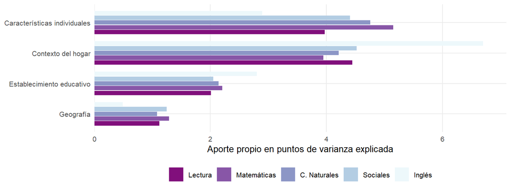

Figura 8

```r
COMPONENTES <- c("Lectura", "Matemáticas", "C. Naturales", "Sociales", "Inglés")

ap <- as.data.frame(as.table(100 * bloques$propio))
names(ap) <- c("bloque", "prueba", "valor")
ap$prueba <- factor(COMPONENTES[as.integer(ap$prueba)], levels = COMPONENTES)
ap$bloque <- factor(unname(NOMBRE_BLOQUE[as.character(ap$bloque)]),
                    levels = unname(NOMBRE_BLOQUE))

p_ap <- ggplot(ap, aes(valor, forcats::fct_rev(bloque), fill = prueba)) +
  geom_col(position = position_dodge(width = 0.78), width = 0.72) +
  scale_fill_brewer(palette = "BuPu", direction = -1) +
  scale_x_continuous(expand = expansion(mult = c(0, 0.06))) +
  labs(x = "Aporte propio en puntos de varianza explicada", y = NULL, fill = NULL) +
  theme(legend.position = "bottom")

exportar_fig(p_ap, "fig-aportes", alto = 2.9)
```

## 3.4 Verificación de supuestos

Esta sección queda preparada para que se redacte el apartado 6 del documento. Cada bloque imprime una sola cosa y lleva encima la frase que dice qué es.

La adecuación muestral del ACP (KMO global, KMO por variable y esfericidad de Bartlett) no está aquí sino en la sección 3.1, junto al análisis que la necesita.

Base de trabajo de esta sección: los registros completos en las doce explicativas, los cinco puntajes y los dos índices del ICFES. `mod` es el modelo multivariado con las doce explicativas.

```r
dsup <- sin_orden(droplevels(
  dataset[complete.cases(dataset[, c(todas, VARS_PUNTAJES, VARS_INDICES,
                                     "PUNT_GLOBAL")]),
          c(todas, VARS_PUNTAJES, VARS_INDICES, "PUNT_GLOBAL")]))

mod <- ajustar_modelo(dsup, todas)
c(observaciones = nrow(dsup))
```

```
observaciones
       478169
```

**Multicolinealidad.** Factores de inflación de varianza generalizados. El primer cuadro usa las doce explicativas del modelo y el segundo añade los dos índices del ICFES, que es donde cabe esperar redundancia. Con factores se lee `vif_eq`, comparable con el VIF corriente.

```r
round(colinealidad(dsup, todas), 3)
```

```
                              gvif gl vif_eq
ESTU_GENERO                  1.079  1  1.079
EDAD_TRAMO                   1.450  4  1.097
ESTU_DEDICACIONLECTURADIARIA 1.091  4  1.022
ESTU_HORASSEMANATRABAJA      1.165  4  1.039
FAMI_ESTRATO_G               1.524  5  1.088
FAMI_EDUCMADRE_G             1.477  4  1.102
FAMI_NUMLIBROS               1.240  3  1.074
FAMI_TIENEINTERNET           1.398  1  1.398
COLE_NATURALEZA              1.682  1  1.682
COLE_JORNADA                 2.295  5  1.181
COLE_AREA_UBICACION          1.207  1  1.207
COLE_REGION                  1.428  5  1.074
```

```r
round(colinealidad(dsup, c(todas, VARS_INDICES)), 3)
```

```
                              gvif gl vif_eq
ESTU_GENERO                  1.083  1  1.083
EDAD_TRAMO                   1.459  4  1.099
ESTU_DEDICACIONLECTURADIARIA 1.094  4  1.023
ESTU_HORASSEMANATRABAJA      1.206  4  1.048
FAMI_ESTRATO_G               1.861  5  1.132
FAMI_EDUCMADRE_G             2.171  4  1.214
FAMI_NUMLIBROS               1.391  3  1.116
FAMI_TIENEINTERNET           1.993  1  1.993
COLE_NATURALEZA              1.892  1  1.892
COLE_JORNADA                 2.497  5  1.201
COLE_AREA_UBICACION          1.388  1  1.388
COLE_REGION                  1.560  5  1.093
ESTU_INSE_INDIVIDUAL         4.477  1  4.477
ESTU_NSE_ESTABLECIMIENTO     3.449  3  1.511
```

**Normalidad.** Asimetría y curtosis de los residuos de cada componente. Con $n$ del orden de $10^5$ las pruebas formales rechazan cualquier desviación, así que se describen los momentos.

```r
round(forma_residuos(mod), 3)
```

```
                         asimetria curtosis
PUNT_LECTURA_CRITICA         0.025    0.191
PUNT_MATEMATICAS             0.088    0.619
PUNT_C_NATURALES             0.132    0.232
PUNT_SOCIALES_CIUDADANAS     0.176    0.152
PUNT_INGLES                  0.621    1.314
```

**Homocedasticidad.** Desviación estándar de los residuos de Lectura Crítica por decil del valor ajustado. Si el supuesto se sostiene, los diez valores son parecidos entre sí.

```r
res <- residuals(mod)[, 1]
aju <- fitted(mod)[, 1]
round(tapply(res, cut(aju, quantile(aju, 0:10 / 10), include.lowest = TRUE,
                      labels = 1:10), sd), 3)
```

```
    1     2     3     4     5     6     7     8     9    10
8.111 8.555 8.751 8.898 8.888 8.933 8.976 8.877 8.751 8.422
```

**Contraste conjunto.** MANOVA de tipo II con el estadístico de Pillai, el más robusto ante desviaciones de la normalidad multivariada. Con esta cantidad de registros la significancia no informa, de modo que lo que se lee es el tamaño del estadístico.

```r
car::Manova(mod, type = "II")
```

```
Type II MANOVA Tests: Pillai test statistic
                             Df test stat approx F num Df  den Df
ESTU_GENERO                   1  0.033534   3318.0      5  478126
EDAD_TRAMO                    4  0.040846    986.5     20 1912516
ESTU_DEDICACIONLECTURADIARIA  4  0.026040    626.6     20 1912516
ESTU_HORASSEMANATRABAJA       4  0.020410    490.4     20 1912516
FAMI_ESTRATO_G                5  0.022094    424.4     25 2390650
FAMI_EDUCMADRE_G              4  0.032313    778.8     20 1912516
FAMI_NUMLIBROS                3  0.019735    633.2     15 1434384
FAMI_TIENEINTERNET            1  0.009764    942.8      5  478126
COLE_NATURALEZA               1  0.011231   1086.2      5  478126
COLE_JORNADA                  5  0.028386    546.0     25 2390650
COLE_AREA_UBICACION           1  0.009338    901.3      5  478126
COLE_REGION                   5  0.022595    434.1     25 2390650
                                            Pr(>F)
ESTU_GENERO                  < 0.00000000000000022 ***
EDAD_TRAMO                   < 0.00000000000000022 ***
ESTU_DEDICACIONLECTURADIARIA < 0.00000000000000022 ***
ESTU_HORASSEMANATRABAJA      < 0.00000000000000022 ***
FAMI_ESTRATO_G               < 0.00000000000000022 ***
FAMI_EDUCMADRE_G             < 0.00000000000000022 ***
FAMI_NUMLIBROS               < 0.00000000000000022 ***
FAMI_TIENEINTERNET           < 0.00000000000000022 ***
COLE_NATURALEZA              < 0.00000000000000022 ***
COLE_JORNADA                 < 0.00000000000000022 ***
COLE_AREA_UBICACION          < 0.00000000000000022 ***
COLE_REGION                  < 0.00000000000000022 ***
---
Signif. codes:  0 '***' 0.001 '**' 0.01 '*' 0.05 '.' 0.1 ' ' 1
```

**Linealidad.** Media del puntaje global por decil del índice socioeconómico, y comparación del $r^2$ lineal con el $\eta^2$ de la versión discretizada. Si la relación es lineal, los dos valores quedan cerca y las medias por decil suben de forma pareja.

```r
dec <- cut(dsup$ESTU_INSE_INDIVIDUAL,
           quantile(dsup$ESTU_INSE_INDIVIDUAL, 0:10 / 10),
           include.lowest = TRUE, labels = 1:10)
round(tapply(dsup$PUNT_GLOBAL, dec, mean), 1)
```

```
    1     2     3     4     5     6     7     8     9    10
220.7 226.2 231.6 237.2 243.0 248.6 254.6 262.1 272.4 295.7
```

```r
c(r2_lineal = round(cor(dsup$ESTU_INSE_INDIVIDUAL, dsup$PUNT_GLOBAL)^2, 4),
  eta2_deciles = round(eta2(dsup$PUNT_GLOBAL, dec), 4))
```

```
   r2_lineal eta2_deciles
      0.2037       0.2025
```

**Independencia.** No se cumple y no hay nada que calcular. Los estudiantes están anidados en colegios y la base publicada no trae identificador de establecimiento, así que no se puede estimar un modelo multinivel ni agrupar los errores estándar. El efecto es que los errores estándar quedan subestimados, lo que no afecta a los $R^2$ ni a los tamaños de efecto, que es sobre lo que se apoya la lectura del documento.

**El ACM** no exige supuestos distribucionales, solo frecuencias suficientes por categoría, que es lo que garantiza la agrupación descrita en la sección 3.2.